# RetEx FID ou Retour d'Expérience du Forum d'Innovation de la Défense

# -) Intro

L'Agence de l'Innovation de la Défense (AID) a organisé le Forum d'Innovation de la Défense (FID) pour une durée de 3 jours à partir du jeudi 22 novembre à la cité de la mode et du design (Paris, voir photo).

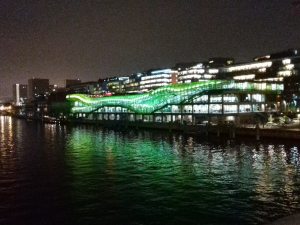

**Présentation** : 160 innovations présentées, 50 conférences et, en cadeau, une démonstration surprise (pour moi) par les forces spéciales de vol au dessus de la seine sur "squatte volant" (Plateforme Individuelle Volante monsieur). En réel la démonstration était très impressionnante. Sur [[youtube](https://www.youtube.com/watch?time_continue=5&v=HDAgCrbQJZo)], seulement 100 vues.

**Diversités** : les conférences vont des grandisimes chefs des Armées au PDG de Qwant en passant par un invité d'honneur : l'aviateur de solar impulse. Et les expositions ou innovations des 2 dernières années sont trop nombreuses pour les citer. Certaines sont listées à la fin de cette page.

La ministre des Armées inaugure le Forum par la brillante citation que vous trouvez juste en dessous.

# 1) Ministre des Armées : Ouverture

> "Ils ne savaient pas que c'était impossible alors ils l'ont fait." (Mark Twain, États-Unis, 1835)

[figure not shown]

**Le terrain change** : omniprésence du numérique, guerres non conventionnelles. C'est pourquoi l'Armée doit s'adapter, innover. De plus cette semaine de l'innovation publique répond à une action nationale et quand la France appelle les Armées répondent toujours présent.

Ces innovations ne sont que **la partie émergée de l'iceberg**. Derrière elles, il y a tous ceux qui ont travaillé, conçu, cherché, les innovations en interne (dites du quotidien) et les résultats qu'entraineront toutes ces innovations.

Il y a 18 mois, nous nous sommes mis en ordre de bataille pour cette bataille de l'innovation. Nous avons renforcé le projet **RAPID**. Des juristes et acheteurs réfléchissent à innover dans les **protocoles d'achats** du **plus grand acheteur de l'Etat**.  
Pour superviser, coordonner ces actions nous avons crée l'Agence d'Innovation de la Défense (1.2G€/an).  
**DefInvest** piloté par la DGA permet de financer des **startups**, il a effectué 4 investissements. A l'image de celui dans une méthode de fabrication d'**un métal ultra résistant à base de poudre**, DefInvest démontre qu'**en terme d'innovation, civil et militaire ne sauraient être séparés**. Laissons entrer l'économie civil au sein du ministère des Armées.

La DGA devient flexible pour répondre aux changements rapides.

IA : 10M€ en 2017 -> 100M€/an en 2022. Mon message est clair :

> Geeks de toutes la France, bienvenue.

# 2) CEA : Centre d'Energie Atomique

[figure not shown]

Le CEA ici représenté par un grand vulgarisateur (voir [[la physique dans starwars](https://www.connaissancedesenergies.org/sites/default/files/pdf-actualites/roland-lehoucq_faire-des-sciences-avec-star-wars_numerique.pdf)]), professeur d'astrophysique à l'X (notamment). présente l'innovation et les ruptures. Ou plutôt l'importance de la science fiction (SF).

## La science fiction a 5 actions :

1. Divination : "La fonction de la SF n'est pas seulement de prédire le futur mais aussi de l'empêcher" (Ray Bradbuty)
2. Prophétie
3. Utopie / Dystopie
4. Futurologie
5. Prospective : Au moyen de la SF, l'humanité peut effectuer des expériences trop dangereuses pour la vie réelle.
- La SF est la littérature avec le plus d'impact politique. C'est pourquoi la Chine a interdit la SF qui se projette vers le futur.
- L'**optatif** : mode de conjugaison du Grec ancien pour se référer à une potentialité désirable.

## La science fiction, une source d'inspiration ?

Un tableau de l'innovation :

- 1945, Arthur Clarke : Idée de satellites géostationnaires pour la télécom
- Jadis, Jules Vernes : Nemo le détective des océans fait prendre conscience que si vous avez un sous-marin vous êtes, impunément, le maître des mers.
- Ce n'est pas difficile d'inventer le cheval à moteur lorsque le cheval et le moteur existent. C'est plus difficile de prévoir les bouchons engendrés par de telles machines dans le futur.

> "Ce sera possible 50 ans après que les gens cessent d'en rigoler" (Clarke, 1917 UK)"

Clarke se référait à l'ascenseur spatiale qui est ajd la plus grande difficultés de la colonisation de l'espace.

- "Quand un savant distingué vieillissant estime que quelque chose est possible il a presque toujours raison mais lorsqu'il déclare que c'est impossible, il a probablement tort." (1er loi de Clarke)
- "Toute technologie suffisamment avancée est indiscernable de la magie." (3eme loi de Clarke)

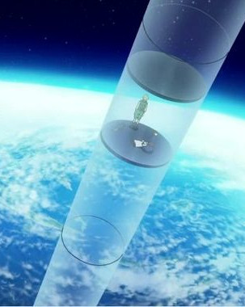

La science fiction :

- Permet une défixation
- Crée un futur désirable
- révèle à choix stratégiques

Alors innovez fainéants !

> "L'avenir ne peut pas être prédit, mais on peut inventer des futurs" (Gabore, dit en 1963, maintes fois mal interprétés).

# 3) État Major des Armées

Les chefs d'états major des 3 principales Armées (mer 3 étoiles, terre 4 et air 5) nous présentent les enjeux de l'innovation. Ils sont tellement d'accords, que l'auteur ne prendra pas le soin de spécifier qui a dit quoi.

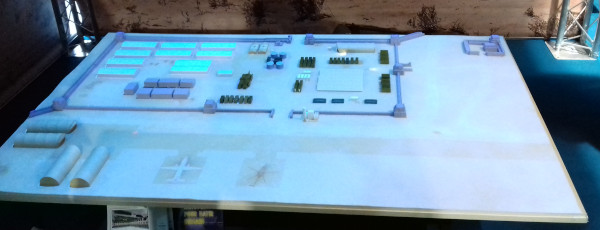

## Innover pour vaincre

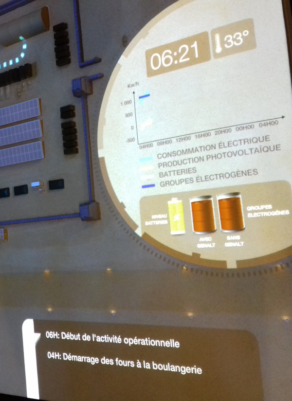

- Il existe une limite pour toute chose et il faut la dépasser en sortant du carcan des idées statiques du 1/2 savoir.
- Le monde change, l'omniprésence des ordiphones pénétrera le MinArm. Le programme Scorpion, il y a 20 ans a anticipé ceci (heureusement).

> Le terrien est culturellement innovant.
- Dans l'innovation, il n'y a pas uniquement le techico-opérationel mais aussi la doctrine, le managérial ou l'organisationnel (et même la bouffe).

> Dès qu'un bateau quitte son port, il est en opex
- Modularité : si un système de système (aussi appelé bateau par le peuple) n'est pas imaginé modulaire (comme les constructions de nos amis SSI) dès le début, pb !! Étonnez-vous !
  - 40 ans : vie d'un bateau
  - 20 ans : vie d'une arme (canon qu'on dit chez nous)
  - 3 ans : vie d'un ordinateur

  Il faut donc évidemment pouvoir changer 1 truc sans tout changé. Le papier toilette est donc indépendant du moteur.

La dualité **autonomie, discrétion** (pour vivre heureux, je vis caché), versus **collectivité, collaboration** (dis moi quand tu vois un missile qui me fonce dessus stp) mais aussi le nombre réduit de personnes sur les bateaux, remplacés par des machines sans compter qu'un bateau est un lieu de vie (vivre loin et longtemps) nous poussent à innover pour l'opérationnel et la vie quotidienne:

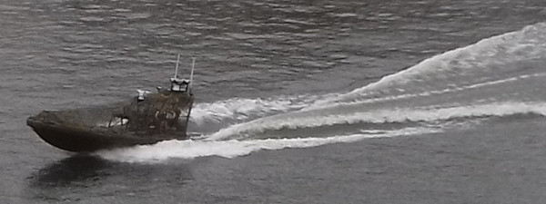

1. Traitement de l'information pour identifier le méchant
2. Mise en œuvre des armes (le sonar doit voir l'arme ennemie de demain ou est inutile)
3. Soutenabilité (formation)

## Pourquoi l'Agence Innovation Défense (1.2G€/an) ?

Le monde libère les esprits. L'Armée ne peut se permettre de les barricader et prendre par là du retard. En un mot l'AID est bien vue. L'AID permet de :

1. Coller le temps court aux temps long (ex : drone, cyber). de Villiers : "On ne sait pas ce que sera l'ordiphone (i.e. le gadget) de 2040". On ne peut donc pas commencer sa construction aujourd'hui.
2. Accélérer, maturer, passer à l'échelle (càd en production).
3. Concilier et rendre modulaire l'innovation des forces et des industrielles.

## Est ce que l'Armée Française a un retard technologique par rapport aux autres armées ?

- ++ Sous-marins, on est (très) forts.
- -- Drone, on est (carrément) nuls. On en demande des retex à des alliés étonnés de voir qu'on ne savait pas à quoi ça ressemblait (un drone qui porte un drone en l'occurrence).
- Ce serait enrichissant et possible d'avoir des drones intelligents antimissiles dans les avions ou pour explorer les coins pourris.
- La relation **homme - machine** c'est que la machine fait tout ce qu'elle peut mais **seul l'humain tue**.
  - Le travail du soldat est si vaste (se déplacer, rendre compte ...) que, même en se restreignant à la partie non létale, beaucoup de missions peuvent être donnée à la machine autonome.
  - La **complexité des règles d'engagements** est à ne pas sous-estimer (et n'est pas facilement écrivable avec des 0 et des 1)
  - **Machine meutrière** : on peut le concevoir en pensant aux humains kamikazes du passé. On en veut pas dans nos Armées.
- Un frein à l'innovation est la communication et on souhaiterait que le message suivant soit largement communiqué.

> On ne veux plus entendre, dans les Armées, la réponse "parce qu'on a toujours fait comme ça".

# 4) Cyber et Renseignement

Le renseignement militaire innove via ateliers en interne depuis quelques (5) ans, et puisque l'on innove pas seul et que l'innovation pousse à se reproduire, quelques projets aboutis visaient à se propager pour collaborer. Comme le 1er concourt publique de l'innovation qui réunira 1700 lycéens ou la simple présence de ces agences à des forums ou conférences qui n'est pas veille de 3 ans.

> Est-ce qu'on est capables de travailler sur nos problèmes ? Les ingénieurs pensent aux solutions mais ne placent pas le problème au centre des préoccupations.

[figure not shown]

Sur le terrain, l'innovation qui s'accompagne de technologies du futur permet de :

1. Aider à la décision
2. Prévoir les prochains conflits
3. Soutient en renseignement sur le terrain qui permet de "tirer les opérations". (Mais surtout de diminuer les risques qu'encourent les ops).

Problème de Big Data : (n° de capteur ↗) x (Capacité des capteurs ↗), ça devient plus que chaud, impossible parfois. Il faut de l'IA.

> Tout le monde pense innovation technique mais elle est aussi dans les esprits.

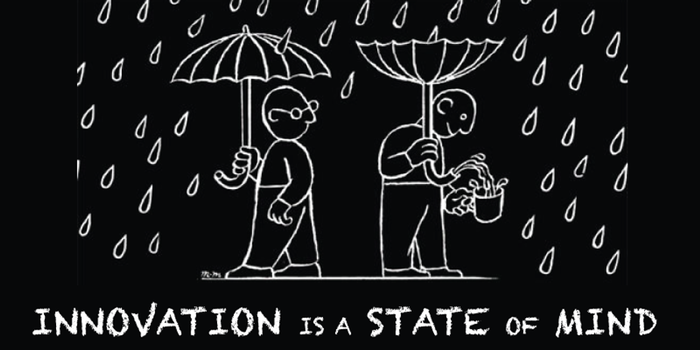

# 5) Solar Impulse par Bertrand Piccard qui en a eut l'idée

[figure not shown]

Introduit d'une vidéo magnifique au volume un peu fort d'un avion qui plane et te fait planait (y avait-il des ondes différentielles dans le son, ou un euphorisant dans le café), Bertrand Piccard répond présent à l'invitation du MinArm qui considère qu'il nous prouve qu'on peut encore être un aventurier aujourd'hui. Le discours est fluide, dense et poétique, si travaillé que l'orateur transite avec brio entre technique et rhétorique comme l'illustre la citation suivante :

> Dans les chemins de l'humain comme dans ceux d'une montgolfière, vous devez changer d'altitude pour changer de direction
1. Monte en notant les vents pour chaque altitude
2. Choisit ton altitude pour avoir le vent dans le dos

Peut être que tu garderas ton altitude initiale, mais par décision et non conviction (i.e. mal éclairée).

[figure not shown]

L'innovation exige en effet de se libérer de notre manière de **penser habituelle et rassurante**, nos **dogmes**, **paradigmes**, **certitudes**, **croyances**, **convictions** (il m'a appris des mots, moi j'appelle tout ça le **conformisme** intellectuel). Par exemple, la téléphonie était "impossible" car nécessitant mettre un fil entre chaque paire d'humain. La "simple" invention de la centrale téléphonique a donné l'étincelle au feu des télécommunications.

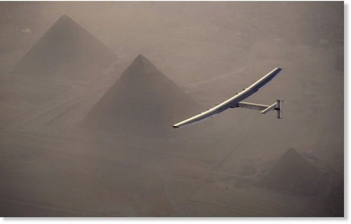

**Aviation** : seuls les dieux avaient le droit de voler, du temps des égyptiens ou de Vinci, qui les 2 en avaient la techno.

**Himalaya** : Les Népalais ne voulaient pas transgresser les lois de la montagne, mais ils avaient la capacité de monter (à poils).

Ces exemples montrent que c'est de **renoncer à un vieille croyance** qui a permis **Himalaya**, **Lune**, **fosses Mariane**, **aviation** ...

**Montgolfière** : le ciel n'est pas la limite de l'humain, c'est le carburant. Je m'en suis rendu compte après mon tour de la terre, avec mes réserves d'hydrogène quasiment épuisées.

> Tu n'y arriveras pas car ça n'a jamais été fait (Indus aéronautique)

Vous serez **humiliés**, **découragés**, **désespérés**. Votre échec sera à l'endroit où vous êtes arrêté. Si vous continuez, peut-être que vous y arriverez. (Sérieusement, n'est pas à ce moment qu'on reconnaît les héros ?)

> Il nous fallait quelqu'un qui ne savait pas que c'était impossible

Un armateur de bateau, à l'aide de fibres de carbone pouvait "construire un matériau aussi léger qu'vous voulez".  
Qui l'eut cru, pas moi mais à postériori, évidement j'ai compris que l'innovation venait toujours de l'extérieur du système. Ici en l'occurrence aucun fabricant d'avions n'a financé le projet.

## Changer de paradigme : **décroissance** -> croissance propre

> Ce ne sont pas les meilleurs fabricants de bougies qui ont inventé l'ampoule électrique

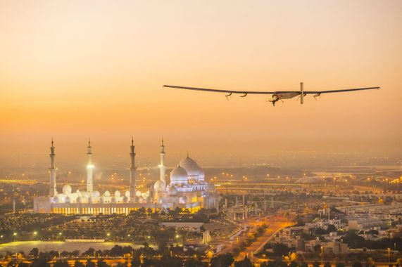

Depuis 50 ans, les écologistes préconisent la **décroissance**. Cela n'a pas beaucoup convaincu encore moins marché. Il faut changer de paradigme. Cherchons à trouver comment la protection de l'environnement peut être enrichissante.

**Croissance propre** : gagner plus d'argent sans produire plus.

Il faut rassembler et non cliver. Faire le moins de perdants possibles. Les entreprises pétrolières deviendront énergétiques. Si on considère que ceux qui polluent sont les coupables, on reste dans l'ancien paradigme. Et quoi qu'on fasse, le monde change et continuera à changer :

- Les jeunes veulent donner un sens à leur métier
- La taxe Carbone en Suède a rendu les entreprises plus compétitives via moins de gaspillage.
- 1/2 de l'énergie produite est gaspillée.
- Le pétrole, c'est le début de la fin. En Arabie Saoudite, on achète 2 cent/kwh l'énergie solaire (versus 15 en France).
- Si tu ne comprends pas les messages précédent tu disparaîtras à l'image de Kodac qui ne comprenait pas la Compact Camera Device (CCD).

Dans les airs, seul dans ton avion sans bruit, tu penses être dans le futur. En réalisant que c'est le présent, tu te rends compte combien le peuple vit dans le passé.

## Et maintenant : 1000 solutions rentables pour protéger l'environnement

Nous cherchons à passer à l'échelle (en nous reproduisant plutôt qu'en grandissant). Nous avons proposé de labelliser 1000 projets écologiques en garantissant leur rentabilité financière. 1400 entreprises ont postulé et déjà 100 projets sont admis.  
Dans un deuxième temps, nous montrerons ces 1000 projets au monde, chefs d'états et entreprises, garantissant par là une communication internationale, et la preuve qu'on peut être écologique ET rentable.

[figure not shown]

# 6) Armée spatiale (3.6G€) et CNES (2.4G€)

L'espace, pour écouter, regarder, communiquer, se positionner, appuyer devient un enjeu mondial et n'est plus réservé aux plus riches. Universités, particuliers, PME y trouvent quelques nanoplaces.

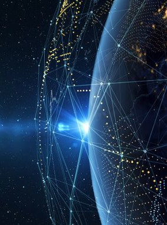

La ministre a dit au CNES le 7 Septembre 2018, nous voulons :

1. Savoir ce qui se passe dans l'espace
2. Conserver notre liberté
3. Une organisation civico-militaire

**New Space** -> Innovation d'opportunités : les nanos sattelites incitent la prise de risque, l'audace et peut-être que l'offre créera un besoin comme l'a fait Facebook.

**Militaires | Civils && Cyber | Espace**, tous sont liés. Il faut donner la main aux privés comme le font USA et Chine

La **territorialisation de l'espace** est dans le futur, il faut s'y préparer.

[figure not shown]

**Aerospace Valley** crée pour faire de l'innovation dans le sud ouest, ouvrir les portes entre certains bâtiments séparés par la confidentialité (militaire, commerciale ou protocolaire). Ils opèrent suivant une stratégie incrémentale et agile, où chaque membre, projet peut se brancher suivant une structure en réseau et non pyramidale. C'est destiner à être agile. Par ailleurs, le CNES a une direction de l'innovation (comme le MinArm).

**Débris spatiaux** : Il y a 14.000 débris de plus de 10cm.  
La France est le pays avec la loi la plus stricte sur les déchets spatiaux. La menace est sérieuse. Concernant l'impact sur les autres pays, les orateurs espèrent enclencher un cercle vertueux quand chacun cherche à avoir belle image. De plus, la France fait exemple (jurisprudence) et met la barre haut pour tous.

# 7) Militaires / DGA / Industriels, comment permettre des cycles courts

**Cause** : les technologies de rupture : virtualisation, radio, big data, objets connectés, ordinateur quantique. La liste s'est vite allongée, il est probable qu'elle en fasse de même les 20 prochaines années.

[figure not shown]

**Problématique** : ces technologies sont des menaces et des opportunités. Dans les 2 cas, il faut être rapide. Comment brancher ces technologies rapides dans une structure lente (la DGA) ?

Les secteurs les plus impactés :

[figure not shown]

1. Réseaux pour assurer la communication
2. Cybersécurité : se défendre des virus
3. Traitement de l'information (langue, image, vidéo, texte)

L'opérationnel est nécessaire DANS le cycle de production, sinon, la réponse au cahier des charges viens déjà trop tard.

La DGA veut des experts:

1. avec du **talent**
2. **Co-créatifs**
3. Sachant être **au bon endroit** au bon moment

[figure not shown]

**Thales** : Analyse des comportements anormaux. Méfiance ...  
**Atos** : "Nous avons une approche orientée client de bout en bout". (Ou "après avoir pénétré, il faut traverser et ressortir" ou dans le contexte "on ne consulte pas le client uniquement lors de la commande et de la livraison")  
**Prosem** : IA pour l'analyse sémantique. (Ça marche, testé par Thales et Atos : mission de sous-traitance parfaitement réussi)

**TestMeThatShit** : une nouvelle **agilité contractuelle** : une demande de la DGA à un indus (ou PME) de tester un produit.

# 8) Qwant : le moteur de recherche qui ne sauvegarde pas vos données

- Les seuls à ne pas avoir tes recherches sous juridiction USA.
- Français, ils se tournent vers la Chine et cherchent à se reproduire plus qu'à grandir :

> Il vaut mieux 100 entreprises de 1G€ que 1 entreprise de 100G€". C'est plus résilient et difficilement achetable.
- Un jour ces entreprises géreront (dans l'ordre de leur création) : email, IA, peer2peer, drive, video hosting ...

[figure not shown]

- Google a copié leur logo quand ils étaient petits (souvenirs d'enfance traumatisants et difficultés en communication)
- Google (encore eux) payent 9G€ à Apple pour rester son moteur de recherche par défaut.
- 100% énergie verte, 0 Carbone, 0 pauvreté

## Tes (bio)données ne sont pas vendre

En effet, elles ne sont pas le fruit de ton travail, même si aujourd'hui évalué à 8€/an/personne, Qwant ne veut PAS en faire commerce, ni en manipuler.

> Je vous rappel que je suis Corse, vous ne voulez pas me donner votre numéro de carte bancaire
- Facebookman s'adresse à Qwantman : "Je ne pense pas que mes données seront revendues prochainement". Le lendemain, 50M comptes ont leaké.
- Grinder est un eforum ayant revendu l'information de séropositivité de ses membres

## RD focalisée sur l'IA :

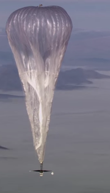

Qwant utilise le médical et la radio comme terrain d'expérimentation. Dans le médical, le traitement d'images permet de localiser les zones de fibrum dans le vagin, ce qui permet de les retirer en laissant le vagin à la patiente. Pour la radio, avec l'accord de l'Armée (de l'air), Qwant a étudié un canal radio pas trop contaminé et découverte beaucoup de véhicules incluant les ballons Google survolant impunément tout territoire.

- Anticiper ou détecter les départs de feux et aider les avions bombardiers d'eau à aller chercher l'eau sans percuter de bateau.
- Anticiper les collisions de bateaux
- Donner la météo, partout
- Donner les horaires de bus

[figure not shown]

- On peut prédire les collisions, on veut faire passer l'info pour que les gens utilisent nos robots.
- On aime Nvidia, le pdg (orateur) est jury représentant des clients de Nvidia. Qwant est un très bon client.
- On met des faux visages sur les gens pour les anonymiser au lieu de chercher qui ils sont :

> Les Chinois sont les meilleurs en reconnaissance de visage mais nous sommes les meilleurs pour les cacher

# +) Forums

Il y avait 160 forums dont l'IA au service du traitement de données des écoutes tempest (écoute des ondes émises dans l'air par les microcomposants).

[figure not shown]

- Laboca : Les rations de survie et vêtements sont testés en cycles courts
- EMA : Des datascientists à Balard travaillent pour l'EMA
- Les linguistes d'écoutes cherchent des traducteurs (humains)
- Transmissions : communication via "des électrodes" sur la peau (des cuisses). Ça libère les mains, yeux et oreilles. (J'ai vu qu'aux USA, certains aveugles pouvaient "voir" grâce à ce mécanisme sur le ventre)
- Data Energie 360 : que le MinArm joue les financiers sur les consommations, le prix de l'électricité, car ces fluctuations dévalisent le pays et l'affaibliraient en temps de crise.
- Conjoints de Marins, la crypto à votre service, un p'tit cout de fil ?
- Véhicules : c'est pas mon truc les grosses bagnoles, mais quand elles sont solaires et autonomes sur tous terrains (sable), c'est le truc du MinArm.
- Plateau de jeu interactif pour l'aide au commandement qui donne sérieusement envie de jouer les chefs, mais pour de la fausse.
- Macoy-3D : pour le guidage : une lentille 2D, comme son nom ne l'indique pas occupe moins de place à embarquer. C'est un prisme de Risley (chercher Risley Prism Beam Pointer)
- Miroir déformable (i.e optique adaptative aux turbulences atmosphériques), pour regarder la terre depuis l'espace. L'inverse se fait avec plus de fonds et moins de nuages au Chili.
- Des simulations :
  - Avions (entrainement en VR)
  - Ondes de chocs
  - Hémorragies
  - Maintenance des navires
- Resolve : radiogognomètres mis en réseaux.
- Crypto asymétriques sur réseaux Euclidiens (Roazon attitude) afin d'être robuste au déchiffrement quantique.
- FuildTracks : Surveillance de foules
- Drone Porteur de Charges Variables : permettant de faire 1 drone pour 1000 usages (French attitude)
- TacView : débriefing automatique (via un soft trop facile à écrire pour qu'il y ait une version commerciale dans le civil)
- EcoCamp : le camp militaire écologique car c'est souvent plus opérationnel et versatile = durable et sans gaspillage
- Moteurs supraconducteurs
- Interrupteurs ergonomiques et où on ne se prend pas de 100.000V dans la tronche si on a les mains mouillées : guidage magnétique et étanchéité

[figure not shown]

- Champs solaires dans une base miliaire : Ici l'innovation consiste "seulement" à "foutre le bordel dans le merdier". Brancher deux technologies existantes est "facile" mais il faut le faire, un exemple d'innovation. Un autre bel exemple de la sorte est l'idée de brancher une culture de bactéries qui mangent du CO2 pour produire du combustible à une centrale d'incinération. En voyant ces jeux gagnants - gagnants, on ne peut que se rappeler que l'important est de participer.
- Tissus transpirants pour quand les avions ont chaud (dans la chambre de combustion)
- Dataviz : du JS pour visualiser les données du MinArm à l'EMA
- Morphy : stockage polymorphe d'Hydrogène pour les besoins énergétiques du fantassin
- Drones sous-marins
- 2ACI : Acquisition Automatique des Cibles par Imagerie
- Earthab (ou un mot proche) : Détection automatique sur images satellites pour le renseignement.
- Dermosquelette pour accompagner l'effort (Safran)
- Icar : automatiser la gestion de véhicule : savoir lequel est où
- Vision infrarouge : des nouvelles jumelles existent, elles n'embarquent pas un réfrigérateur.

Tinmarino.